# Project - FMST

**Data Discription** - The actual concrete compressive strength (MPa) for a given mixture under a specific age (days) was determined from laboratory. Data is in raw form (not scaled). The data has 8 quantitative input variables, and 1 quantitative output variable, and 1030 instances (observations).

**Context** - Concrete is the most important material in civil engineering. The concrete compressive strength is a highly nonlinear function of age and ingredients. These ingredients include cement, blast furnace slag, fly ash, water, superplasticizer, coarse aggregate, and fine aggregate.

**Objective** - Modeling of strength of high performance concrete using Machine Learning

```python
#Importing standard Libraries
import pandas as pd
import numpy as np
import seaborn as sns
import matplotlib.pyplot as plt
from sklearn.preprocessing import StandardScaler
from scipy.stats import zscore

#Import Sklearn package's data splitting function which is based on random function
from sklearn.model_selection import train_test_split
# Import Linear Regression, Ridge and Lasso machine learning library
from sklearn.linear_model import LinearRegression, Ridge, Lasso
# Import KNN Regressor machine learning library
from sklearn.neighbors import KNeighborsRegressor
# Import Decision Tree Regressor machine learning library
from sklearn.tree import DecisionTreeRegressor
# Import ensemble machine learning library
from sklearn.ensemble import (RandomForestRegressor, GradientBoostingRegressor,AdaBoostRegressor,BaggingRegressor)
#Import the metrics
from sklearn import metrics
#importing the K fold
from sklearn.model_selection import KFold
#importing the cross validation score
from sklearn.model_selection import cross_val_score
from sklearn.utils import resample
```

```python
#load the csv file and make the dataframe
df  = pd.read_csv('concrete.csv')
```

```python
#Getting a glimpse of the head of the dataframe
df.head()
```

|  | cement | slag | ash | water | superplastic | coarseagg | fineagg | age | strength |
| --- | --- | --- | --- | --- | --- | --- | --- | --- | --- |
| 0 | 141.3 | 212.0 | 0.0 | 203.5 | 0.0 | 971.8 | 748.5 | 28 | 29.89 |
| 1 | 168.9 | 42.2 | 124.3 | 158.3 | 10.8 | 1080.8 | 796.2 | 14 | 23.51 |
| 2 | 250.0 | 0.0 | 95.7 | 187.4 | 5.5 | 956.9 | 861.2 | 28 | 29.22 |
| 3 | 266.0 | 114.0 | 0.0 | 228.0 | 0.0 | 932.0 | 670.0 | 28 | 45.85 |
| 4 | 154.8 | 183.4 | 0.0 | 193.3 | 9.1 | 1047.4 | 696.7 | 28 | 18.29 |

```python
#Shape of the data
print("The dataframe has {} rows and {} columns".format(df.shape[0],df.shape[1]))
```

```
The dataframe has 1030 rows and 9 columns
```

**Attribute Information**:  
cement - Cement : measured in kg in a m3 mixture  
slag - Blast : measured in kg in a m3 mixture  
ash - Fly ash : measured in kg in a m3 mixture  
water - Water : measured in kg in a m3 mixture  
superplastic - Superplasticizer : measured in kg in a m3 mixture  
courseagg - Coarse Aggregate : measured in kg in a m3 mixture  
fineagg - Fine Aggregate : measured in kg in a m3 mixture  
age - Age : day (1~365)  
strenght - Concrete compressive strength measured in MPa

```python
#Attribute information
df.info()
```

```
<class 'pandas.core.frame.DataFrame'>
RangeIndex: 1030 entries, 0 to 1029
Data columns (total 9 columns):
 #   Column        Non-Null Count  Dtype
---  ------        --------------  -----
 0   cement        1030 non-null   float64
 1   slag          1030 non-null   float64
 2   ash           1030 non-null   float64
 3   water         1030 non-null   float64
 4   superplastic  1030 non-null   float64
 5   coarseagg     1030 non-null   float64
 6   fineagg       1030 non-null   float64
 7   age           1030 non-null   int64
 8   strength      1030 non-null   float64
dtypes: float64(8), int64(1)
memory usage: 72.5 KB
```

```python
#fucntion to check how many null values are there
df.apply(lambda x: sum(x.isnull()))
```

```
cement          0
slag            0
ash             0
water           0
superplastic    0
coarseagg       0
fineagg         0
age             0
strength        0
dtype: int64
```

```python
#5 point summary
df.describe().transpose()
```

|  | count | mean | std | min | 25% | 50% | 75% | max |
| --- | --- | --- | --- | --- | --- | --- | --- | --- |
| cement | 1030.0 | 281.167864 | 104.506364 | 102.00 | 192.375 | 272.900 | 350.000 | 540.0 |
| slag | 1030.0 | 73.895825 | 86.279342 | 0.00 | 0.000 | 22.000 | 142.950 | 359.4 |
| ash | 1030.0 | 54.188350 | 63.997004 | 0.00 | 0.000 | 0.000 | 118.300 | 200.1 |
| water | 1030.0 | 181.567282 | 21.354219 | 121.80 | 164.900 | 185.000 | 192.000 | 247.0 |
| superplastic | 1030.0 | 6.204660 | 5.973841 | 0.00 | 0.000 | 6.400 | 10.200 | 32.2 |
| coarseagg | 1030.0 | 972.918932 | 77.753954 | 801.00 | 932.000 | 968.000 | 1029.400 | 1145.0 |
| fineagg | 1030.0 | 773.580485 | 80.175980 | 594.00 | 730.950 | 779.500 | 824.000 | 992.6 |
| age | 1030.0 | 45.662136 | 63.169912 | 1.00 | 7.000 | 28.000 | 56.000 | 365.0 |
| strength | 1030.0 | 35.817961 | 16.705742 | 2.33 | 23.710 | 34.445 | 46.135 | 82.6 |

## Univariate Analysis

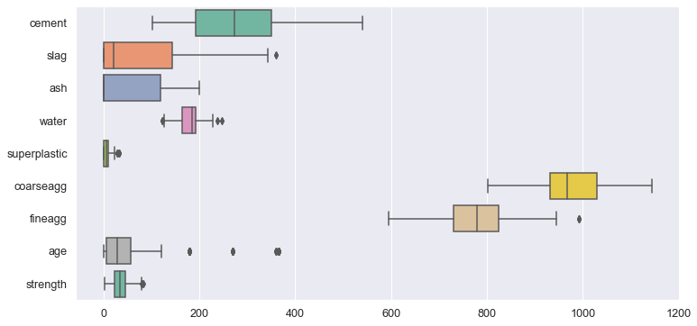

```python
plt.figure(figsize=(12,6))
sns.boxplot(data=df, orient='h', palette='Set2', dodge=False)
```

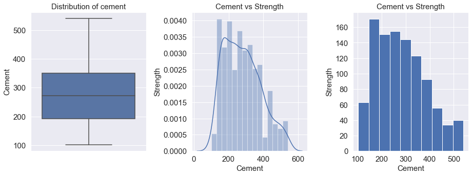

```python
fig, (ax1,ax2,ax3)=plt.subplots(1,3,figsize=(13,5))

#boxplot
sns.boxplot(x='cement',data=df,orient='v',ax=ax1)
ax1.set_ylabel('Cement', fontsize=15)
ax1.set_title('Distribution of cement', fontsize=15)
ax1.tick_params(labelsize=15)

#distplot
sns.distplot(df['cement'],ax=ax2)
ax2.set_xlabel('Cement', fontsize=15)
ax2.set_ylabel('Strength', fontsize=15)
ax2.set_title('Cement vs Strength', fontsize=15)
ax2.tick_params(labelsize=15)

#histogram
ax3.hist(df['cement'])
ax3.set_xlabel('Cement', fontsize=15)
ax3.set_ylabel('Strength', fontsize=15)
ax3.set_title('Cement vs Strength', fontsize=15)
ax3.tick_params(labelsize=15)

plt.subplots_adjust(wspace=0.5)
plt.tight_layout()
```

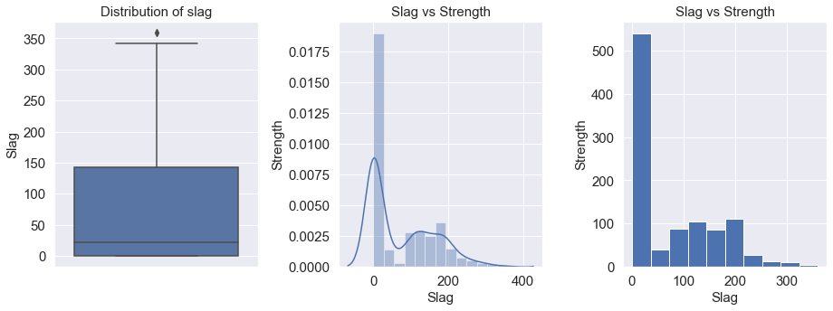

```python
fig, (ax1,ax2,ax3)=plt.subplots(1,3,figsize=(13,5))

#boxplot
sns.boxplot(x='slag',data=df,orient='v',ax=ax1)
ax1.set_ylabel('Slag', fontsize=15)
ax1.set_title('Distribution of slag', fontsize=15)
ax1.tick_params(labelsize=15)

#distplot
sns.distplot(df['slag'],ax=ax2)
ax2.set_xlabel('Slag', fontsize=15)
ax2.set_ylabel('Strength', fontsize=15)
ax2.set_title('Slag vs Strength', fontsize=15)
ax2.tick_params(labelsize=15)

#histogram
ax3.hist(df['slag'])
ax3.set_xlabel('Slag', fontsize=15)
ax3.set_ylabel('Strength', fontsize=15)
ax3.set_title('Slag vs Strength', fontsize=15)
ax3.tick_params(labelsize=15)

plt.subplots_adjust(wspace=0.5)
plt.tight_layout()
```

```python
#Checking Outliers
outlier_columns = []

Q1 =  df['slag'].quantile(0.25) # 1st Quartile
Q3 =  df['slag'].quantile(0.75) # 3rd Quartile
IQR = Q3 - Q1  # Interquartile range

LTV_slag = Q1 - 1.5 * IQR   # lower bound
UTV_slag = Q3 + 1.5 * IQR   # upper bound

print('Interquartile range = ', IQR)
print('slag <',LTV_slag ,'and >',UTV_slag, ' are outliers')
print('Numerber of outliers in slag column below the lower whisker =', df[df['slag'] < (Q1-(1.5*IQR))]['slag'].count())
print('Numerber of outliers in slag column above the upper whisker =', df[df['slag'] > (Q3+(1.5*IQR))]['slag'].count())

# storing column name and upper-lower bound value where outliers are present
outlier_columns.append('slag')
upperLowerBound_Disct = {'slag':UTV_slag}
```

```
Interquartile range =  142.95
slag < -214.42499999999998 and > 357.375  are outliers
Numerber of outliers in slag column below the lower whisker = 0
Numerber of outliers in slag column above the upper whisker = 2
```

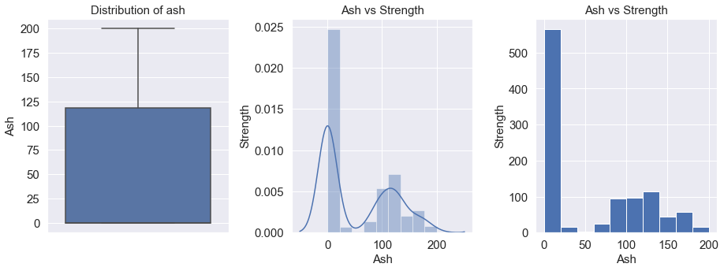

```python
fig, (ax1,ax2,ax3)=plt.subplots(1,3,figsize=(13,5))

#boxplot
sns.boxplot(x='ash',data=df,orient='v',ax=ax1)
ax1.set_ylabel('Ash', fontsize=15)
ax1.set_title('Distribution of ash', fontsize=15)
ax1.tick_params(labelsize=15)

#distplot
sns.distplot(df['ash'],ax=ax2)
ax2.set_xlabel('Ash', fontsize=15)
ax2.set_ylabel('Strength', fontsize=15)
ax2.set_title('Ash vs Strength', fontsize=15)
ax2.tick_params(labelsize=15)

#histogram
ax3.hist(df['ash'])
ax3.set_xlabel('Ash', fontsize=15)
ax3.set_ylabel('Strength', fontsize=15)
ax3.set_title('Ash vs Strength', fontsize=15)
ax3.tick_params(labelsize=15)

plt.subplots_adjust(wspace=0.5)
plt.tight_layout()
```

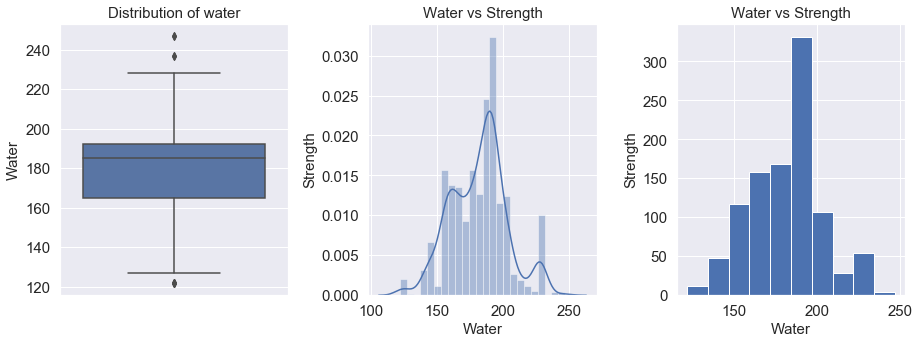

```python
fig, (ax1,ax2,ax3)=plt.subplots(1,3,figsize=(13,5))

#boxplot
sns.boxplot(x='water',data=df,orient='v',ax=ax1)
ax1.set_ylabel('Water', fontsize=15)
ax1.set_title('Distribution of water', fontsize=15)
ax1.tick_params(labelsize=15)

#distplot
sns.distplot(df['water'],ax=ax2)
ax2.set_xlabel('Water', fontsize=15)
ax2.set_ylabel('Strength', fontsize=15)
ax2.set_title('Water vs Strength', fontsize=15)
ax2.tick_params(labelsize=15)

#histogram
ax3.hist(df['water'])
ax3.set_xlabel('Water', fontsize=15)
ax3.set_ylabel('Strength', fontsize=15)
ax3.set_title('Water vs Strength', fontsize=15)
ax3.tick_params(labelsize=15)

plt.subplots_adjust(wspace=0.5)
plt.tight_layout()
```

```python
#Checking Outliers

Q1 =  df['water'].quantile(0.25) # 1st Quartile
Q3 =  df['water'].quantile(0.75) # 3rd Quartile
IQR = Q3 - Q1  # Interquartile range

LTV_water = Q1 - 1.5 * IQR   # lower bound
UTV_water = Q3 + 1.5 * IQR   # upper bound

print('Interquartile range = ', IQR)
print('water <',LTV_water ,'and >',UTV_water, ' are outliers')
print('Numerber of outliers in water column below the lower whisker =', df[df['water'] < (Q1-(1.5*IQR))]['water'].count())
print('Numerber of outliers in water column above the upper whisker =', df[df['water'] > (Q3+(1.5*IQR))]['water'].count())

# storing column name and upper-lower bound value where outliers are present
outlier_columns.append('water')
upperLowerBound_Disct['water_LTV'] = LTV_water
upperLowerBound_Disct['water_UTV'] = UTV_water
```

```
Interquartile range =  27.099999999999994
water < 124.25000000000001 and > 232.64999999999998  are outliers
Numerber of outliers in water column below the lower whisker = 5
Numerber of outliers in water column above the upper whisker = 4
```

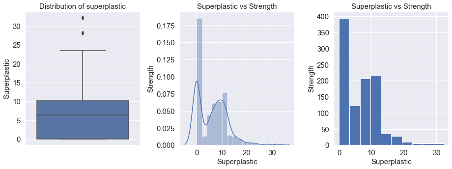

```python
fig, (ax1,ax2,ax3)=plt.subplots(1,3,figsize=(13,5))

#boxplot
sns.boxplot(x='superplastic',data=df,orient='v',ax=ax1)
ax1.set_ylabel('Superplastic', fontsize=15)
ax1.set_title('Distribution of superplastic', fontsize=15)
ax1.tick_params(labelsize=15)

#distplot
sns.distplot(df['superplastic'],ax=ax2)
ax2.set_xlabel('Superplastic', fontsize=15)
ax2.set_ylabel('Strength', fontsize=15)
ax2.set_title('Superplastic vs Strength', fontsize=15)
ax2.tick_params(labelsize=15)

#histogram
ax3.hist(df['superplastic'])
ax3.set_xlabel('Superplastic', fontsize=15)
ax3.set_ylabel('Strength', fontsize=15)
ax3.set_title('Superplastic vs Strength', fontsize=15)
ax3.tick_params(labelsize=15)

plt.subplots_adjust(wspace=0.5)
plt.tight_layout()
```

```python
#Checking Outliers

Q1 =  df['superplastic'].quantile(0.25) # 1st Quartile
Q3 =  df['superplastic'].quantile(0.75) # 3rd Quartile
IQR = Q3 - Q1  # Interquartile range

LTV_superplastic = Q1 - 1.5 * IQR   # lower bound
UTV_superplastic = Q3 + 1.5 * IQR   # upper bound

print('Interquartile range = ', IQR)
print('superplastic <',LTV_superplastic ,'and >',UTV_superplastic, ' are outliers')
print('Numerber of outliers in superplastic column below the lower whisker =', df[df['superplastic'] < (Q1-(1.5*IQR))]['superplastic'].count())
print('Numerber of outliers in superplastic column above the upper whisker =', df[df['superplastic'] > (Q3+(1.5*IQR))]['superplastic'].count())

# storing column name and upper-lower bound value where outliers are present
outlier_columns.append('superplastic')
upperLowerBound_Disct['superplastic'] = UTV_superplastic
```

```
Interquartile range =  10.2
superplastic < -15.299999999999999 and > 25.5  are outliers
Numerber of outliers in superplastic column below the lower whisker = 0
Numerber of outliers in superplastic column above the upper whisker = 10
```

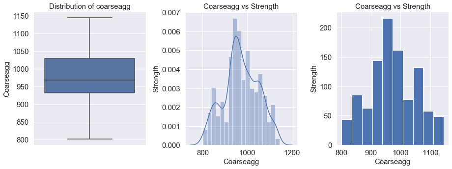

```python
fig, (ax1,ax2,ax3)=plt.subplots(1,3,figsize=(13,5))

#boxplot
sns.boxplot(x='coarseagg',data=df,orient='v',ax=ax1)
ax1.set_ylabel('Coarseagg', fontsize=15)
ax1.set_title('Distribution of coarseagg', fontsize=15)
ax1.tick_params(labelsize=15)

#distplot
sns.distplot(df['coarseagg'],ax=ax2)
ax2.set_xlabel('Coarseagg', fontsize=15)
ax2.set_ylabel('Strength', fontsize=15)
ax2.set_title('Coarseagg vs Strength', fontsize=15)
ax2.tick_params(labelsize=15)

#histogram
ax3.hist(df['coarseagg'])
ax3.set_xlabel('Coarseagg', fontsize=15)
ax3.set_ylabel('Strength', fontsize=15)
ax3.set_title('Coarseagg vs Strength', fontsize=15)
ax3.tick_params(labelsize=15)

plt.subplots_adjust(wspace=0.5)
plt.tight_layout()
```

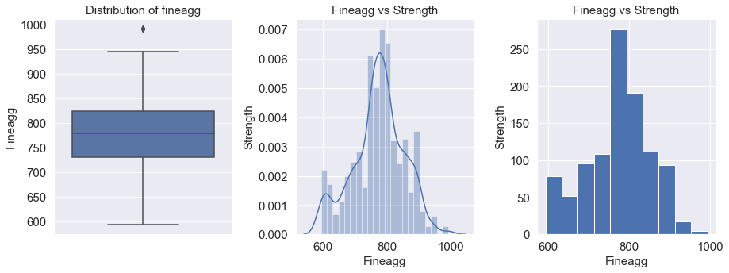

```python
fig, (ax1,ax2,ax3)=plt.subplots(1,3,figsize=(13,5))

#boxplot
sns.boxplot(x='fineagg',data=df,orient='v',ax=ax1)
ax1.set_ylabel('Fineagg', fontsize=15)
ax1.set_title('Distribution of fineagg', fontsize=15)
ax1.tick_params(labelsize=15)

#distplot
sns.distplot(df['fineagg'],ax=ax2)
ax2.set_xlabel('Fineagg', fontsize=15)
ax2.set_ylabel('Strength', fontsize=15)
ax2.set_title('Fineagg vs Strength', fontsize=15)
ax2.tick_params(labelsize=15)

#histogram
ax3.hist(df['fineagg'])
ax3.set_xlabel('Fineagg', fontsize=15)
ax3.set_ylabel('Strength', fontsize=15)
ax3.set_title('Fineagg vs Strength', fontsize=15)
ax3.tick_params(labelsize=15)

plt.subplots_adjust(wspace=0.5)
plt.tight_layout()
```

```python
#Checking Outliers

Q1 =  df['fineagg'].quantile(0.25) # 1st Quartile
Q3 =  df['fineagg'].quantile(0.75) # 3rd Quartile
IQR = Q3 - Q1  # Interquartile range

LTV_fineagg = Q1 - 1.5 * IQR   # lower bound
UTV_fineagg = Q3 + 1.5 * IQR   # upper bound

print('Interquartile range = ', IQR)
print('fineagg <',LTV_fineagg ,'and >',UTV_fineagg, ' are outliers')
print('Numerber of outliers in fineagg column below the lower whisker =', df[df['fineagg'] < (Q1-(1.5*IQR))]['fineagg'].count())
print('Numerber of outliers in fineagg column above the upper whisker =', df[df['fineagg'] > (Q3+(1.5*IQR))]['fineagg'].count())

# storing column name and upper-lower bound value where outliers are present
outlier_columns.append('fineagg')
upperLowerBound_Disct['fineagg'] = UTV_fineagg
```

```
Interquartile range =  93.05000000000007
fineagg < 591.3749999999998 and > 963.575  are outliers
Numerber of outliers in fineagg column below the lower whisker = 0
Numerber of outliers in fineagg column above the upper whisker = 5
```

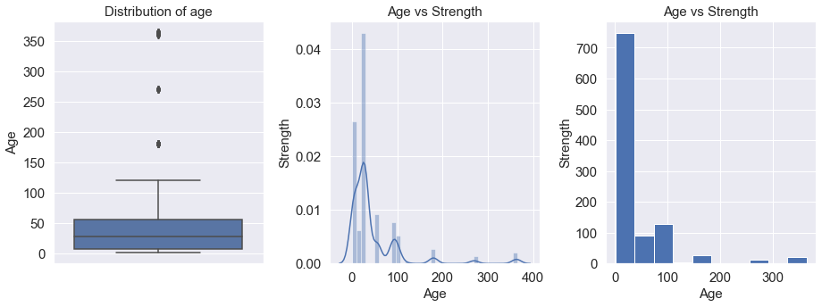

```python
fig, (ax1,ax2,ax3)=plt.subplots(1,3,figsize=(13,5))

#boxplot
sns.boxplot(x='age',data=df,orient='v',ax=ax1)
ax1.set_ylabel('Age', fontsize=15)
ax1.set_title('Distribution of age', fontsize=15)
ax1.tick_params(labelsize=15)

#distplot
sns.distplot(df['age'],ax=ax2)
ax2.set_xlabel('Age', fontsize=15)
ax2.set_ylabel('Strength', fontsize=15)
ax2.set_title('Age vs Strength', fontsize=15)
ax2.tick_params(labelsize=15)

#histogram
ax3.hist(df['age'])
ax3.set_xlabel('Age', fontsize=15)
ax3.set_ylabel('Strength', fontsize=15)
ax3.set_title('Age vs Strength', fontsize=15)
ax3.tick_params(labelsize=15)

plt.subplots_adjust(wspace=0.5)
plt.tight_layout()
```

```python
#Checking Outliers

Q1 =  df['age'].quantile(0.25) # 1st Quartile
Q3 =  df['age'].quantile(0.75) # 3rd Quartile
IQR = Q3 - Q1  # Interquartile range

LTV_age = Q1 - 1.5 * IQR   # lower bound
UTV_age = Q3 + 1.5 * IQR   # upper bound

print('Interquartile range = ', IQR)
print('age <',LTV_age ,'and >',UTV_age, ' are outliers')
print('Numerber of outliers in age column below the lower whisker =', df[df['age'] < (Q1-(1.5*IQR))]['age'].count())
print('Numerber of outliers in age column above the upper whisker =', df[df['age'] > (Q3+(1.5*IQR))]['age'].count())

# storing column name and upper-lower bound value where outliers are present
outlier_columns.append('age')
upperLowerBound_Disct['age'] = UTV_age
```

```
Interquartile range =  49.0
age < -66.5 and > 129.5  are outliers
Numerber of outliers in age column below the lower whisker = 0
Numerber of outliers in age column above the upper whisker = 59
```

## Multivariate Analysis

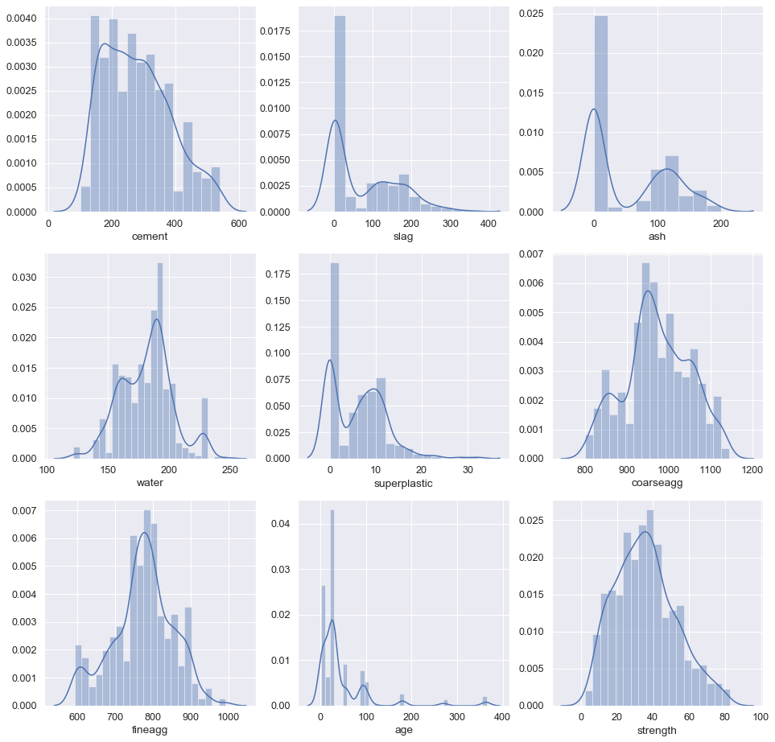

```python
# Distplot
fig, ax2 = plt.subplots(3, 3, figsize=(16, 16))
sns.distplot(df['cement'],ax=ax2[0][0])
sns.distplot(df['slag'],ax=ax2[0][1])
sns.distplot(df['ash'],ax=ax2[0][2])
sns.distplot(df['water'],ax=ax2[1][0])
sns.distplot(df['superplastic'],ax=ax2[1][1])
sns.distplot(df['coarseagg'],ax=ax2[1][2])
sns.distplot(df['fineagg'],ax=ax2[2][0])
sns.distplot(df['age'],ax=ax2[2][1])
sns.distplot(df['strength'],ax=ax2[2][2])
```

**Observation**

We can see observe that :

cement is almost normal.  
slag has three gausssians and rightly skewed.  
ash has two gaussians and rightly skewed.  
water has three guassians and slighly left skewed.  
superplastic has two gaussians and rightly skewed.  
coarseagg has three guassians and almost normal.  
fineagg has almost two guassians and looks like normal.  
age has multiple guassians and rightly skewed.

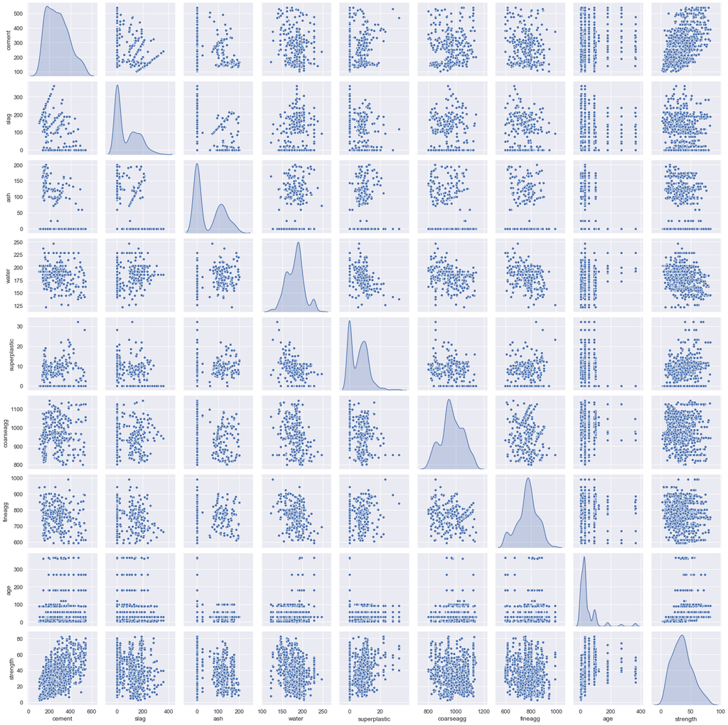

```python
sns.pairplot(df ,diag_kind='kde')
```

**Relationship between indpendent attributes**

Scatter plots:

cement vs other independent attributes: This attribute does not have any significant relation with slag, ash, water, superplatic, coarseagg,fineagg and age. It almost spread like a cloud.  
slag vs other independent attributes: This attribute also does not have any significant relation with ash, water, superplatic, coarseagg,fineagg and age. It almost spread like a cloud.

ash vs other independent attributes: This attribute also does not have any significant relation with water, superplatic, coarseagg,fineagg and age. It almost spread like a cloud.

water vs other independent attributes: This attribute have negative linear relationship with superplastic and fineagg. It does not have any significant relationship with other independent atributes. This is true as Superplasticizers allows the reduction of water in the concrete upto the a certain extent without reducing the flexibility to mold the concrete.

superplastic vs other independent attributes:This attribute have negative linear relationship with water only. It does not have any significant relationship with other independent attributes.

coarseagg vs other independent attributes:This attribute also does not have any significant relation with any other attributes. It almost spread like a cloud.

fineagg vs other independent attributes:It has negative linear relationship with water. It does not have any significant relation with any other attributes. It almost spread like a cloud.

**Relationship between dependent and independent attributes**

Lets compare the target column with other independent attributes.

strength vs cement: It is linearly related to the cement. The relationship is positive and we can see that for a given value of cement we have a multiple values of strength. Which one should we pick we don't know. Hence Cement though it has positive relationship with the strength, is a weak predictor.  
strength vs slag: There is no particular trend.  
strength vs slag: There is also no particular trend.  
strength vs age: For a given value of age, we have different values of strength. Hence, It is not a good predictor.  
strength vs superplastic:For a given value of age, we have different values of strength. Hence, It is not a good predictor.  
Other attributes does not give any strong relationship with strength. Hence, we can see that none of the independent attributes **alone** are good predictors of the target.  
There is a no linear relationship between them. So, we will not use Linear model

```python
# corrlation matrix
corr=df.corr()
corr
```

|  | cement | slag | ash | water | superplastic | coarseagg | fineagg | age | strength |
| --- | --- | --- | --- | --- | --- | --- | --- | --- | --- |
| cement | 1.000000 | -0.275216 | -0.397467 | -0.081587 | 0.092386 | -0.109349 | -0.222718 | 0.081946 | 0.497832 |
| slag | -0.275216 | 1.000000 | -0.323580 | 0.107252 | 0.043270 | -0.283999 | -0.281603 | -0.044246 | 0.134829 |
| ash | -0.397467 | -0.323580 | 1.000000 | -0.256984 | 0.377503 | -0.009961 | 0.079108 | -0.154371 | -0.105755 |
| water | -0.081587 | 0.107252 | -0.256984 | 1.000000 | -0.657533 | -0.182294 | -0.450661 | 0.277618 | -0.289633 |
| superplastic | 0.092386 | 0.043270 | 0.377503 | -0.657533 | 1.000000 | -0.265999 | 0.222691 | -0.192700 | 0.366079 |
| coarseagg | -0.109349 | -0.283999 | -0.009961 | -0.182294 | -0.265999 | 1.000000 | -0.178481 | -0.003016 | -0.164935 |
| fineagg | -0.222718 | -0.281603 | 0.079108 | -0.450661 | 0.222691 | -0.178481 | 1.000000 | -0.156095 | -0.167241 |
| age | 0.081946 | -0.044246 | -0.154371 | 0.277618 | -0.192700 | -0.003016 | -0.156095 | 1.000000 | 0.328873 |
| strength | 0.497832 | 0.134829 | -0.105755 | -0.289633 | 0.366079 | -0.164935 | -0.167241 | 0.328873 | 1.000000 |

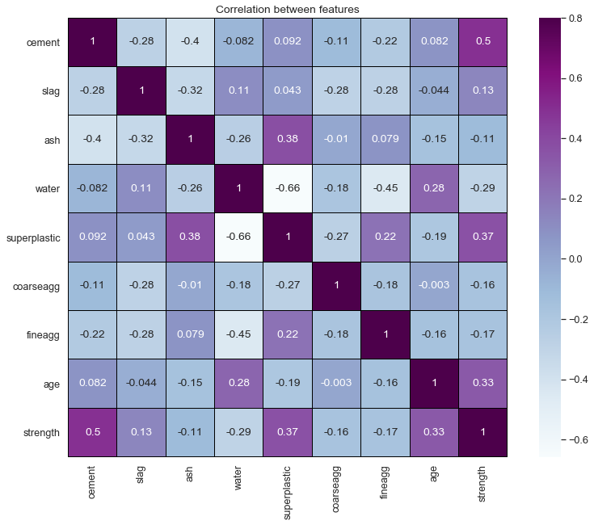

```python
#heatmap
sns.set(font_scale=1.15)
plt.figure(figsize=(14, 10))

sns.heatmap(corr, vmax=.8, linewidths=0.01,
            square=True,annot=True,cmap="BuPu",linecolor="black")
plt.title('Correlation between features');
```

Here, water shows a negative relationship with superplastic (as discussed, water and superplastic have somewhat opposite effects on the fuilidty/plasticity of the concrete mix) and fineagg. Also, the map shows some what of a positive relationship with slag and age.  
No significant correlations clearly stand out.  
We'll move on to correcting the present outliers.

## Outliers

```python
print('These are the columns which have outliers : \n\n',outlier_columns)
print('\n\nUpper and/or lower range of detected outliers\n',upperLowerBound_Disct)
```

```
These are the columns which have outliers :

 ['slag', 'water', 'superplastic', 'fineagg', 'age']


Upper and/or lower range of detected outliers
 {'slag': 357.375, 'water_LTV': 124.25000000000001, 'water_UTV': 232.64999999999998, 'superplastic': 25.5, 'fineagg': 963.575, 'age': 129.5}
```

```python
#Number of outliers present in the dataset
print('Number of outliers in cement: ',df[((df.cement - df.cement.mean()) / df.cement.std()).abs() >3]['cement'].count())
print('Number of outliers in slag: ',df[((df.slag - df.slag.mean()) / df.slag.std()).abs() >3]['slag'].count())
print('Number of outliers in ash: ',df[((df.ash - df.ash.mean()) / df.ash.std()).abs() >3]['ash'].count())
print('Number of outliers in water: ',df[((df.water - df.water.mean()) / df.water.std()).abs() >3]['water'].count())
print('Number of outliers in superplastic: ',df[((df.superplastic - df.superplastic.mean()) / df.superplastic.std()).abs() >3]['superplastic'].count())
print('Number of outliers in coarseagg: ',df[((df.coarseagg - df.coarseagg.mean()) / df.coarseagg.std()).abs() >3]['coarseagg'].count())
print('Number of outliers in fineagg: ',df[((df.fineagg - df.fineagg.mean()) / df.fineagg.std()).abs() >3]['fineagg'].count())
print('Number of outliers in age: ',df[((df.age - df.age.mean()) / df.age.std()).abs() >3]['age'].count())
```

```
Number of outliers in cement:  0
Number of outliers in slag:  4
Number of outliers in ash:  0
Number of outliers in water:  2
Number of outliers in superplastic:  10
Number of outliers in coarseagg:  0
Number of outliers in fineagg:  0
Number of outliers in age:  33
```

We should not simply drop the outliers we have detected because if we drop them then there may be loss of information. We have 2 options to consider from :  
1)We can replace the outliers with the respective medians  
2)We can standardize the columns using z-score and eliminate those outliers beyond +3 or -3 std deviations.  
Let's try to understand the relationships of the features to get some insights.  
All of these features are measured in kg in a m3 mixture and represent the ratio of mixtures except for age which represents number of days. We have fairly low number of outliers for slag, water, superplastic and fineagg which would not affect the overall information by a significant amount, hence they can be dropped via z-score or replaced by medians. However, the age feature has 59 outliers beyond the upper whisker.  
To avoid information loss, it is best to go with replacement with medians for all the features in this case.

```python
#Handling the outliers

#Replacing the outliers by median
for col_name in df.columns[:-1]:
    q1 = df[col_name].quantile(0.25)
    q3 = df[col_name].quantile(0.75)
    iqr = q3 - q1

    low = q1-1.5*iqr
    high = q3+1.5*iqr
    df.loc[(df[col_name] < low) | (df[col_name] > high), col_name] = df[col_name].median()
```

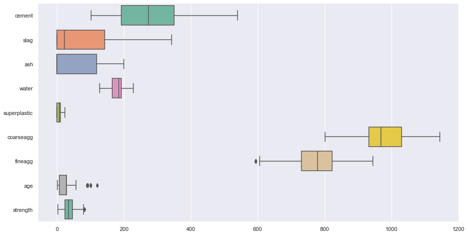

```python
#Visualizing the outliers that still exist
plt.figure(figsize=(15,8))
sns.boxplot(data=df, orient="h", palette="Set2", dodge=False)
```

We have eleminated most outliers by simply replacing for the median. However, a few outliers still exist as shown. Such few numbers will not influence our calculations in predicting concrete strength hence we can ignore them.

```python
#Number of outliers still present in the dataset
print('Number of outliers in cement: ',df[((df.cement - df.cement.mean()) / df.cement.std()).abs() >3]['cement'].count())
print('Number of outliers in slag: ',df[((df.slag - df.slag.mean()) / df.slag.std()).abs() >3]['slag'].count())
print('Number of outliers in ash: ',df[((df.ash - df.ash.mean()) / df.ash.std()).abs() >3]['ash'].count())
print('Number of outliers in water: ',df[((df.water - df.water.mean()) / df.water.std()).abs() >3]['water'].count())
print('Number of outliers in superplastic: ',df[((df.superplastic - df.superplastic.mean()) / df.superplastic.std()).abs() >3]['superplastic'].count())
print('Number of outliers in coarseagg: ',df[((df.coarseagg - df.coarseagg.mean()) / df.coarseagg.std()).abs() >3]['coarseagg'].count())
print('Number of outliers in fineagg: ',df[((df.fineagg - df.fineagg.mean()) / df.fineagg.std()).abs() >3]['fineagg'].count())
print('Number of outliers in age: ',df[((df.age - df.age.mean()) / df.age.std()).abs() >3]['age'].count())
```

```
Number of outliers in cement:  0
Number of outliers in slag:  2
Number of outliers in ash:  0
Number of outliers in water:  0
Number of outliers in superplastic:  5
Number of outliers in coarseagg:  0
Number of outliers in fineagg:  0
Number of outliers in age:  3
```

## Feature Engineering & Model Building

Looking into the features, we understand that these are ingredients to make concrete. Most of the features are in the same measurement units so it seems that there is an opportunity to combine some features.  
As superplastic, coarseagg and fineagg are additives that are purchased, stored and added to the mix seperately, it is best to leave these features as they are.  
We can focus on water, cement, slag and ash to create some composite features.  
However, looking into some basic background of the domain, it is apparent that water and cement are some of the key features that define the outcome of strength. Hence it is not advisable to create a composite of these two features as we will not get to know how much influence does each of the features has. Based on this thought process, it is not advisable to make composite of any of the features as there are no strong correlations and also the domain knowledge sheds light that each feature is an ingredient that is individual to the process of making concrete. Hence we will only go ahead with z-score standardization.

```python
#Scaling the features

df_z = df.apply(zscore)
df_z=pd.DataFrame(df_z,columns=df.columns)
```

```python
#Splitting the data into independent and dependent attributes

#independent and dependent variables
X=df_z.iloc[:,0:8]
y = df_z.iloc[:,8]
```

```python
# Split X and y into training and test set in 70:30 ratio

X_train, X_test, y_train, y_test = train_test_split(X,y, test_size = 0.3, random_state = 1)
```

### Decision Tree

```python
dt_model = DecisionTreeRegressor()
dt_model.fit(X_train , y_train)
```

```
DecisionTreeRegressor(ccp_alpha=0.0, criterion='mse', max_depth=None,
                      max_features=None, max_leaf_nodes=None,
                      min_impurity_decrease=0.0, min_impurity_split=None,
                      min_samples_leaf=1, min_samples_split=2,
                      min_weight_fraction_leaf=0.0, presort='deprecated',
                      random_state=None, splitter='best')
```

### Feature Importance

```python
#printing the feature importance
print('Feature importances: \n',pd.DataFrame(dt_model.feature_importances_,columns=['Imp'],index=X_train.columns))
```

```
Feature importances:
                    Imp
cement        0.352262
slag          0.093872
ash           0.013101
water         0.129807
superplastic  0.018574
coarseagg     0.033264
fineagg       0.030597
age           0.328524
```

cement, age and water are significant attributes.  
Also; ash, coarseagg, fineagg, superplastic and slag are the less significant variable.These will hardly impact target prediction.

```python
y_pred = dt_model.predict(X_test)
# performance on train data
print('Performance on training data using DT:',dt_model.score(X_train,y_train))
# performance on test data
print('Performance on testing data using DT:',dt_model.score(X_test,y_test))
#Evaluate the model using accuracy
acc_DT=metrics.r2_score(y_test, y_pred)
print('Accuracy DT: ',acc_DT)
print('MSE: ',metrics.mean_squared_error(y_test, y_pred))
```

```
Performance on training data using DT: 0.9917907393004437
Performance on testing data using DT: 0.8400690643518061
Accuracy DT:  0.840069064351806
MSE:  0.1669455370880553
```

**Observation**- There is clear overfitting in this case as training is returning 99% accuracy whereas in testing the accuracy drops significantly.

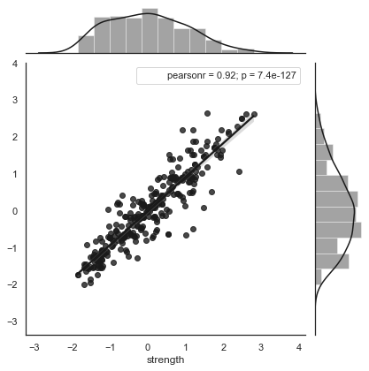

```python
from scipy.stats import pearsonr
sns.set(style="darkgrid", color_codes=True)
with sns.axes_style("white"):
    sns.jointplot(x=y_test, y=y_pred, stat_func=pearsonr,kind="reg", color="k");
```

```python
#Store the accuracy results for each model in a dataframe for final comparison
results = pd.DataFrame({'Method':['Decision Tree'], 'accuracy': acc_DT},index={'1'})
results = results[['Method', 'accuracy']]
results
```

|  | Method | accuracy |
| --- | --- | --- |
| 1 | Decision Tree | 0.840069 |

### K fold cross validation

```python
num_folds = 18
seed = 77
kfold = KFold(n_splits=num_folds, random_state=seed)
results1 = cross_val_score(dt_model,X, y, cv=kfold)
accuracy=np.mean(abs(results1))
print('Average accuracy: ',accuracy)
print('Standard Deviation: ',results1.std())
```

```
Average accuracy:  0.8671777722965467
Standard Deviation:  0.044743639921791895
```

```python
##importing the preprocessing library
#from sklearn import preprocessing
```

```python
#Store the accuracy results for each model in a dataframe for final comparison
tempResultsDf = pd.DataFrame({'Method':['Decision Tree k fold'], 'accuracy': [accuracy]},index={'2'})
results = pd.concat([results, tempResultsDf])
results = results[['Method', 'accuracy']]
results
```

|  | Method | accuracy |
| --- | --- | --- |
| 1 | Decision Tree | 0.840069 |
| 2 | Decision Tree k fold | 0.867178 |

**Iteration #2** - Dropping the least significant variable.

```python
#Create a copy of the dataset
df2=df_z.copy()
```

```python
#independent and dependent variable
X = df2.drop( ['strength','ash','coarseagg','fineagg'] , axis=1)
y = df2['strength']
# Split X and y into training and test set in 70:30 ratio
X_train, X_test, y_train, y_test = train_test_split(X,y, test_size = 0.3, random_state = 1)
```

```python
dt_model = DecisionTreeRegressor()
dt_model.fit(X_train , y_train)
```

```
DecisionTreeRegressor(ccp_alpha=0.0, criterion='mse', max_depth=None,
                      max_features=None, max_leaf_nodes=None,
                      min_impurity_decrease=0.0, min_impurity_split=None,
                      min_samples_leaf=1, min_samples_split=2,
                      min_weight_fraction_leaf=0.0, presort='deprecated',
                      random_state=None, splitter='best')
```

```python
#printing the feature importance
print('Feature importances: \n',pd.DataFrame(dt_model.feature_importances_,columns=['Imp'],index=X_train.columns))
```

```
Feature importances:
                    Imp
cement        0.367442
slag          0.108151
water         0.162068
superplastic  0.033394
age           0.328945
```

```python
y_pred = dt_model.predict(X_test)
# performance on train data
print('Performance on training data using DT:',dt_model.score(X_train,y_train))
# performance on test data
print('Performance on testing data using DT:',dt_model.score(X_test,y_test))
#Evaluate the model using accuracy
acc_DT=metrics.r2_score(y_test, y_pred)
print('Accuracy DT: ',acc_DT)
```

```
Performance on training data using DT: 0.991045963372976
Performance on testing data using DT: 0.8498098358396248
Accuracy DT:  0.8498098358396248
```

**The model is still overfitting even with dropping least important features.**

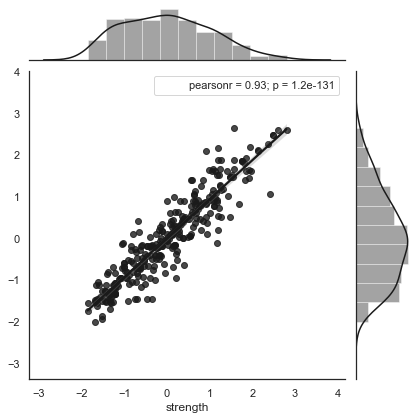

```python
from scipy.stats import pearsonr
sns.set(style="darkgrid", color_codes=True)
with sns.axes_style("white"):
    sns.jointplot(x=y_test, y=y_pred, stat_func=pearsonr,kind="reg", color="k");
```

```python
#Store the accuracy results for each model in a dataframe for final comparison
tempResultsDf = pd.DataFrame({'Method':['Decision Tree Iteration #2'], 'accuracy': [acc_DT]},index={'3'})
results = pd.concat([results, tempResultsDf])
results = results[['Method', 'accuracy']]
results
```

|  | Method | accuracy |
| --- | --- | --- |
| 1 | Decision Tree | 0.840069 |
| 2 | Decision Tree k fold | 0.867178 |
| 3 | Decision Tree Iteration #2 | 0.849810 |

### Pruning of Decision Tree

```python
#independent and dependent variables
X= df_z.iloc[:,0:8]
y = df_z.iloc[:,8]
# Split X and y into training and test set in 70:30 ratio
X_train, X_test, y_train, y_test = train_test_split(X,y, test_size = 0.3, random_state = 1)
```

```python
# Regularizing the Decision tree classifier and fitting the model
reg_dt_model = DecisionTreeRegressor( max_depth = 4,random_state=1,min_samples_leaf=5)
reg_dt_model.fit(X_train, y_train)
```

```
DecisionTreeRegressor(ccp_alpha=0.0, criterion='mse', max_depth=4,
                      max_features=None, max_leaf_nodes=None,
                      min_impurity_decrease=0.0, min_impurity_split=None,
                      min_samples_leaf=5, min_samples_split=2,
                      min_weight_fraction_leaf=0.0, presort='deprecated',
                      random_state=1, splitter='best')
```

```python
print (pd.DataFrame(reg_dt_model.feature_importances_, columns = ["Imp"], index = X_train.columns))
```

```
                   Imp
cement        0.416953
slag          0.025822
ash           0.000000
water         0.135128
superplastic  0.017987
coarseagg     0.000000
fineagg       0.007793
age           0.396318
```

We can see that fineagg, coarseagg and ash are least significant features.

```python
y_pred = reg_dt_model.predict(X_test)
# performance on train data
print('Performance on training data using DT:',reg_dt_model.score(X_train,y_train))
# performance on test data
print('Performance on testing data using DT:',reg_dt_model.score(X_test,y_test))
#Evaluate the model using accuracy
acc_RDT=metrics.r2_score(y_test, y_pred)
print('Accuracy DT: ',acc_RDT)
print('MSE: ',metrics.mean_squared_error(y_test, y_pred))
```

```
Performance on training data using DT: 0.7255811799299218
Performance on testing data using DT: 0.6548277186105129
Accuracy DT:  0.6548277186105129
MSE:  0.36031160369896825
```

```python
#Store the accuracy results for each model in a dataframe for final comparison
tempResultsDf = pd.DataFrame({'Method':['Pruned Decision Tree'], 'accuracy': [acc_RDT]},index={'4'})
results = pd.concat([results, tempResultsDf])
results = results[['Method', 'accuracy']]
results
```

|  | Method | accuracy |
| --- | --- | --- |
| 1 | Decision Tree | 0.840069 |
| 2 | Decision Tree k fold | 0.867178 |
| 3 | Decision Tree Iteration #2 | 0.849810 |
| 4 | Pruned Decision Tree | 0.654828 |

```python
num_folds = 18
seed = 77
kfold = KFold(n_splits=num_folds, random_state=seed)
results1 = cross_val_score(reg_dt_model,X, y, cv=kfold)
accuracy=np.mean(abs(results1))
print('Average accuracy: ',accuracy)
print('Standard Deviation: ',results1.std())
```

```
Average accuracy:  0.6745523114433877
Standard Deviation:  0.08608318690710857
```

```python
#Store the accuracy results for each model in a dataframe for final comparison
tempResultsDf = pd.DataFrame({'Method':['Pruned Decision Tree k fold'], 'accuracy': [accuracy]},index={'5'})
results = pd.concat([results, tempResultsDf])
results = results[['Method', 'accuracy']]
results
```

|  | Method | accuracy |
| --- | --- | --- |
| 1 | Decision Tree | 0.840069 |
| 2 | Decision Tree k fold | 0.867178 |
| 3 | Decision Tree Iteration #2 | 0.849810 |
| 4 | Pruned Decision Tree | 0.654828 |
| 5 | Pruned Decision Tree k fold | 0.674552 |

The accuracy has dropped with pruning the model and performing k fold.

### Random Forest

```python
model=RandomForestRegressor()
model.fit(X_train, y_train)
```

```
RandomForestRegressor(bootstrap=True, ccp_alpha=0.0, criterion='mse',
                      max_depth=None, max_features='auto', max_leaf_nodes=None,
                      max_samples=None, min_impurity_decrease=0.0,
                      min_impurity_split=None, min_samples_leaf=1,
                      min_samples_split=2, min_weight_fraction_leaf=0.0,
                      n_estimators=100, n_jobs=None, oob_score=False,
                      random_state=None, verbose=0, warm_start=False)
```

```python
y_pred = model.predict(X_test)
# performance on train data
print('Performance on training data using RFR:',model.score(X_train,y_train))
# performance on test data
print('Performance on testing data using RFR:',model.score(X_test,y_test))
#Evaluate the model using accuracy
acc_RFR=metrics.r2_score(y_test, y_pred)
print('Accuracy DT: ',acc_RFR)
print('MSE: ',metrics.mean_squared_error(y_test, y_pred))
```

```
Performance on training data using RFR: 0.9796926731398046
Performance on testing data using RFR: 0.902846657741296
Accuracy DT:  0.902846657741296
MSE:  0.10141450644018757
```

There is overfitting observed here since the test accuracy has dropped by 7%.

```python
#Store the accuracy results for each model in a dataframe for final comparison
tempResultsDf = pd.DataFrame({'Method':['Random Forest Regressor'], 'accuracy': [acc_RFR]},index={'7'})
results = pd.concat([results, tempResultsDf])
results = results[['Method', 'accuracy']]
results
```

|  | Method | accuracy |
| --- | --- | --- |
| 1 | Decision Tree | 0.840069 |
| 2 | Decision Tree k fold | 0.867178 |
| 3 | Decision Tree Iteration #2 | 0.849810 |
| 4 | Pruned Decision Tree | 0.654828 |
| 5 | Pruned Decision Tree k fold | 0.674552 |
| 7 | Random Forest Regressor | 0.902847 |

### K fold cross validation

```python
num_folds = 20
seed = 77
kfold = KFold(n_splits=num_folds, random_state=seed)
results1 = cross_val_score(model,X, y, cv=kfold)
accuracy=np.mean(abs(results1))
print('Average accuracy: ',accuracy)
print('Standard Deviation: ',results1.std())
```

```
Average accuracy:  0.9122463736378373
Standard Deviation:  0.029228580216788452
```

```python
#Store the accuracy results for each model in a dataframe for final comparison
tempResultsDf = pd.DataFrame({'Method':['Random Forest Regressor k fold'], 'accuracy': [accuracy]},index={'8'})
results = pd.concat([results, tempResultsDf])
results = results[['Method', 'accuracy']]
results
```

|  | Method | accuracy |
| --- | --- | --- |
| 1 | Decision Tree | 0.840069 |
| 2 | Decision Tree k fold | 0.867178 |
| 3 | Decision Tree Iteration #2 | 0.849810 |
| 4 | Pruned Decision Tree | 0.654828 |
| 5 | Pruned Decision Tree k fold | 0.674552 |
| 7 | Random Forest Regressor | 0.902847 |
| 8 | Random Forest Regressor k fold | 0.912246 |

### Gradient Boosting Regressor

```python
model=GradientBoostingRegressor()
model.fit(X_train, y_train)
```

```
GradientBoostingRegressor(alpha=0.9, ccp_alpha=0.0, criterion='friedman_mse',
                          init=None, learning_rate=0.1, loss='ls', max_depth=3,
                          max_features=None, max_leaf_nodes=None,
                          min_impurity_decrease=0.0, min_impurity_split=None,
                          min_samples_leaf=1, min_samples_split=2,
                          min_weight_fraction_leaf=0.0, n_estimators=100,
                          n_iter_no_change=None, presort='deprecated',
                          random_state=None, subsample=1.0, tol=0.0001,
                          validation_fraction=0.1, verbose=0, warm_start=False)
```

```python
y_pred = model.predict(X_test)
# performance on train data
print('Performance on training data using GBR:',model.score(X_train,y_train))
# performance on test data
print('Performance on testing data using GBR:',model.score(X_test,y_test))
#Evaluate the model using accuracy
acc_GBR=metrics.r2_score(y_test, y_pred)
print('Accuracy DT: ',acc_GBR)
print('MSE: ',metrics.mean_squared_error(y_test, y_pred))
```

```
Performance on training data using GBR: 0.9430469892492805
Performance on testing data using GBR: 0.8916784805730056
Accuracy DT:  0.8916784805730056
MSE:  0.11307252199607824
```

```python
#Store the accuracy results for each model in a dataframe for final comparison
tempResultsDf = pd.DataFrame({'Method':['Gradient Boost Regressor'], 'accuracy': [acc_GBR]},index={'9'})
results = pd.concat([results, tempResultsDf])
results = results[['Method', 'accuracy']]
results
```

|  | Method | accuracy |
| --- | --- | --- |
| 1 | Decision Tree | 0.840069 |
| 2 | Decision Tree k fold | 0.867178 |
| 3 | Decision Tree Iteration #2 | 0.849810 |
| 4 | Pruned Decision Tree | 0.654828 |
| 5 | Pruned Decision Tree k fold | 0.674552 |
| 7 | Random Forest Regressor | 0.902847 |
| 8 | Random Forest Regressor k fold | 0.912246 |
| 9 | Gradient Boost Regressor | 0.891678 |

### K fold cross validation

```python
num_folds = 20
seed = 77
kfold = KFold(n_splits=num_folds, random_state=seed)
results1 = cross_val_score(model,X, y, cv=kfold)
accuracy=np.mean(abs(results1))
print('Average accuracy: ',accuracy)
print('Standard Deviation: ',results1.std())
```

```
Average accuracy:  0.8996451944757377
Standard Deviation:  0.0261793219398342
```

```python
#Store the accuracy results for each model in a dataframe for final comparison
tempResultsDf = pd.DataFrame({'Method':['Gradient Boost Regressor k fold'], 'accuracy': [accuracy]},index={'10'})
results = pd.concat([results, tempResultsDf])
results = results[['Method', 'accuracy']]
results
```

|  | Method | accuracy |
| --- | --- | --- |
| 1 | Decision Tree | 0.840069 |
| 2 | Decision Tree k fold | 0.867178 |
| 3 | Decision Tree Iteration #2 | 0.849810 |
| 4 | Pruned Decision Tree | 0.654828 |
| 5 | Pruned Decision Tree k fold | 0.674552 |
| 7 | Random Forest Regressor | 0.902847 |
| 8 | Random Forest Regressor k fold | 0.912246 |
| 9 | Gradient Boost Regressor | 0.891678 |
| 10 | Gradient Boost Regressor k fold | 0.899645 |

### ADA Boost Regressor

```python
model=AdaBoostRegressor()
model.fit(X_train, y_train)
```

```
AdaBoostRegressor(base_estimator=None, learning_rate=1.0, loss='linear',
                  n_estimators=50, random_state=None)
```

```python
y_pred = model.predict(X_test)
# performance on train data
print('Performance on training data using GBR:',model.score(X_train,y_train))
# performance on test data
print('Performance on testing data using GBR:',model.score(X_test,y_test))
#Evaluate the model using accuracy
acc_ABR=metrics.r2_score(y_test, y_pred)
print('Accuracy DT: ',acc_ABR)
print('MSE: ',metrics.mean_squared_error(y_test, y_pred))
```

```
Performance on training data using GBR: 0.8087196375911223
Performance on testing data using GBR: 0.7461226990595258
Accuracy DT:  0.7461226990595258
MSE:  0.26501240793842584
```

```python
#Store the accuracy results for each model in a dataframe for final comparison
tempResultsDf = pd.DataFrame({'Method':['Ada Boosting Regressor'], 'accuracy': [acc_ABR]},index={'11'})
results = pd.concat([results, tempResultsDf])
results = results[['Method', 'accuracy']]
results
```

|  | Method | accuracy |
| --- | --- | --- |
| 1 | Decision Tree | 0.840069 |
| 2 | Decision Tree k fold | 0.867178 |
| 3 | Decision Tree Iteration #2 | 0.849810 |
| 4 | Pruned Decision Tree | 0.654828 |
| 5 | Pruned Decision Tree k fold | 0.674552 |
| 7 | Random Forest Regressor | 0.902847 |
| 8 | Random Forest Regressor k fold | 0.912246 |
| 9 | Gradient Boost Regressor | 0.891678 |
| 10 | Gradient Boost Regressor k fold | 0.899645 |
| 11 | Ada Boosting Regressor | 0.746123 |

### K fold cross validation

```python
num_folds = 18
seed = 77
kfold = KFold(n_splits=num_folds, random_state=seed)
results1 = cross_val_score(model,X, y, cv=kfold)
accuracy=np.mean(abs(results1))
print('Average accuracy: ',accuracy)
print('Standard Deviation: ',results1.std())
```

```
Average accuracy:  0.7754983351984723
Standard Deviation:  0.04251106852001616
```

```python
tempResultsDf = pd.DataFrame({'Method':['Ada Boosting Regressor k fold'], 'accuracy': [accuracy]},index={'12'})
results = pd.concat([results, tempResultsDf])
results = results[['Method', 'accuracy']]
results
```

|  | Method | accuracy |
| --- | --- | --- |
| 1 | Decision Tree | 0.840069 |
| 2 | Decision Tree k fold | 0.867178 |
| 3 | Decision Tree Iteration #2 | 0.849810 |
| 4 | Pruned Decision Tree | 0.654828 |
| 5 | Pruned Decision Tree k fold | 0.674552 |
| 7 | Random Forest Regressor | 0.902847 |
| 8 | Random Forest Regressor k fold | 0.912246 |
| 9 | Gradient Boost Regressor | 0.891678 |
| 10 | Gradient Boost Regressor k fold | 0.899645 |
| 11 | Ada Boosting Regressor | 0.746123 |
| 12 | Ada Boosting Regressor k fold | 0.775498 |

### Bagging Regressor

```python
model=BaggingRegressor()
model.fit(X_train, y_train)
```

```
BaggingRegressor(base_estimator=None, bootstrap=True, bootstrap_features=False,
                 max_features=1.0, max_samples=1.0, n_estimators=10,
                 n_jobs=None, oob_score=False, random_state=None, verbose=0,
                 warm_start=False)
```

```python
y_pred = model.predict(X_test)
# performance on train data
print('Performance on training data using GBR:',model.score(X_train,y_train))
# performance on test data
print('Performance on testing data using GBR:',model.score(X_test,y_test))
#Evaluate the model using accuracy
acc_BR=metrics.r2_score(y_test, y_pred)
print('Accuracy DT: ',acc_BR)
print('MSE: ',metrics.mean_squared_error(y_test, y_pred))
```

```
Performance on training data using GBR: 0.9743183816415061
Performance on testing data using GBR: 0.8806920238062304
Accuracy DT:  0.8806920238062304
MSE:  0.12454084685887162
```

```python
#Store the accuracy results for each model in a dataframe for final comparison
tempResultsDf = pd.DataFrame({'Method':['Bagging Regressor'], 'accuracy': [acc_BR]},index={'13'})
results = pd.concat([results, tempResultsDf])
results = results[['Method', 'accuracy']]
results
```

|  | Method | accuracy |
| --- | --- | --- |
| 1 | Decision Tree | 0.840069 |
| 2 | Decision Tree k fold | 0.867178 |
| 3 | Decision Tree Iteration #2 | 0.849810 |
| 4 | Pruned Decision Tree | 0.654828 |
| 5 | Pruned Decision Tree k fold | 0.674552 |
| 7 | Random Forest Regressor | 0.902847 |
| 8 | Random Forest Regressor k fold | 0.912246 |
| 9 | Gradient Boost Regressor | 0.891678 |
| 10 | Gradient Boost Regressor k fold | 0.899645 |
| 11 | Ada Boosting Regressor | 0.746123 |
| 12 | Ada Boosting Regressor k fold | 0.775498 |
| 13 | Bagging Regressor | 0.880692 |

### K fold cross validation

```python
num_folds = 20
seed = 77
kfold = KFold(n_splits=num_folds, random_state=seed)
results1 = cross_val_score(model,X, y, cv=kfold)
accuracy=np.mean(abs(results1))
print('Average accuracy: ',accuracy)
print('Standard Deviation: ',results1.std())
```

```
Average accuracy:  0.9019828054870462
Standard Deviation:  0.029929117625961506
```

```python
#Store the accuracy results for each model in a dataframe for final comparison
tempResultsDf = pd.DataFrame({'Method':['Bagging Regressor k fold'], 'accuracy': [accuracy]},index={'14'})
results = pd.concat([results, tempResultsDf])
results = results[['Method', 'accuracy']]
results
```

|  | Method | accuracy |
| --- | --- | --- |
| 1 | Decision Tree | 0.840069 |
| 2 | Decision Tree k fold | 0.867178 |
| 3 | Decision Tree Iteration #2 | 0.849810 |
| 4 | Pruned Decision Tree | 0.654828 |
| 5 | Pruned Decision Tree k fold | 0.674552 |
| 7 | Random Forest Regressor | 0.902847 |
| 8 | Random Forest Regressor k fold | 0.912246 |
| 9 | Gradient Boost Regressor | 0.891678 |
| 10 | Gradient Boost Regressor k fold | 0.899645 |
| 11 | Ada Boosting Regressor | 0.746123 |
| 12 | Ada Boosting Regressor k fold | 0.775498 |
| 13 | Bagging Regressor | 0.880692 |
| 14 | Bagging Regressor k fold | 0.901983 |

### KNN Regressor

```python
error=[]
for i in range(1,30):
    knn = KNeighborsRegressor(n_neighbors=i)
    knn.fit(X_train,y_train)
    pred_i = knn.predict(X_test)
    error.append(np.mean(pred_i!=y_test))
```

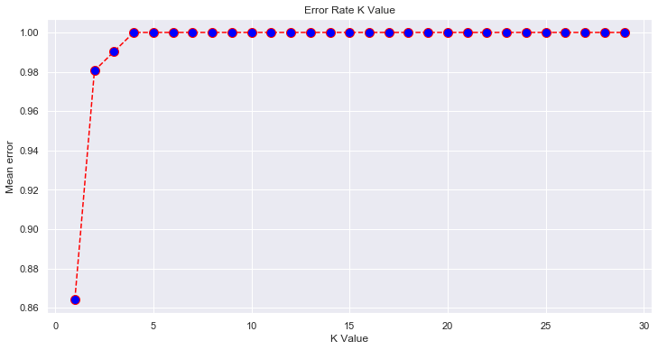

```python
plt.figure(figsize=(12,6))
plt.plot(range(1,30),error,color='red', linestyle='dashed',marker='o',markerfacecolor='blue',markersize=10)
plt.title('Error Rate K Value')
plt.xlabel('K Value')
plt.ylabel('Mean error')
```

```python
#k=3
model = KNeighborsRegressor(n_neighbors=3)
model.fit(X_train, y_train)
```

```
KNeighborsRegressor(algorithm='auto', leaf_size=30, metric='minkowski',
                    metric_params=None, n_jobs=None, n_neighbors=3, p=2,
                    weights='uniform')
```

```python
y_pred = model.predict(X_test)
# performance on train data
print('Performance on training data using KNNR:',model.score(X_train,y_train))
# performance on test data
print('Performance on testing data using KNNR:',model.score(X_test,y_test))
#Evaluate the model using accuracy
acc_K=metrics.r2_score(y_test, y_pred)
print('Accuracy KNNR: ',acc_K)
print('MSE: ',metrics.mean_squared_error(y_test, y_pred))
```

```
Performance on training data using KNNR: 0.8902196318573777
Performance on testing data using KNNR: 0.8078817663272165
Accuracy KNNR:  0.8078817663272165
MSE:  0.20054457616295157
```

```python
#Store the accuracy results for each model in a dataframe for final comparison
tempResultsDf = pd.DataFrame({'Method':['KNN Regressor'], 'accuracy': [acc_K]},index={'15'})
results = pd.concat([results, tempResultsDf])
results = results[['Method', 'accuracy']]
results
```

|  | Method | accuracy |
| --- | --- | --- |
| 1 | Decision Tree | 0.840069 |
| 2 | Decision Tree k fold | 0.867178 |
| 3 | Decision Tree Iteration #2 | 0.849810 |
| 4 | Pruned Decision Tree | 0.654828 |
| 5 | Pruned Decision Tree k fold | 0.674552 |
| 7 | Random Forest Regressor | 0.902847 |
| 8 | Random Forest Regressor k fold | 0.912246 |
| 9 | Gradient Boost Regressor | 0.891678 |
| 10 | Gradient Boost Regressor k fold | 0.899645 |
| 11 | Ada Boosting Regressor | 0.746123 |
| 12 | Ada Boosting Regressor k fold | 0.775498 |
| 13 | Bagging Regressor | 0.880692 |
| 14 | Bagging Regressor k fold | 0.901983 |
| 15 | KNN Regressor | 0.807882 |

### K fold cross validation

```python
num_folds = 30
seed = 77
kfold = KFold(n_splits=num_folds, random_state=seed)
results1 = cross_val_score(model,X, y, cv=kfold)
accuracy=np.mean(abs(results1))
print('Average accuracy: ',accuracy)
print('Standard Deviation: ',results1.std())
```

```
Average accuracy:  0.791265681749521
Standard Deviation:  0.06617056736946313
```

```python
#Store the accuracy results for each model in a dataframe for final comparison
tempResultsDf = pd.DataFrame({'Method':['KNN Regressor k fold'], 'accuracy': [accuracy]},index={'16'})
results = pd.concat([results, tempResultsDf])
results = results[['Method', 'accuracy']]
results
```

|  | Method | accuracy |
| --- | --- | --- |
| 1 | Decision Tree | 0.840069 |
| 2 | Decision Tree k fold | 0.867178 |
| 3 | Decision Tree Iteration #2 | 0.849810 |
| 4 | Pruned Decision Tree | 0.654828 |
| 5 | Pruned Decision Tree k fold | 0.674552 |
| 7 | Random Forest Regressor | 0.902847 |
| 8 | Random Forest Regressor k fold | 0.912246 |
| 9 | Gradient Boost Regressor | 0.891678 |
| 10 | Gradient Boost Regressor k fold | 0.899645 |
| 11 | Ada Boosting Regressor | 0.746123 |
| 12 | Ada Boosting Regressor k fold | 0.775498 |
| 13 | Bagging Regressor | 0.880692 |
| 14 | Bagging Regressor k fold | 0.901983 |
| 15 | KNN Regressor | 0.807882 |
| 16 | KNN Regressor k fold | 0.791266 |

After checking through all these models, it looks like we are obtaining the best accuracy on Random Forest Regressor. We should focus into this model and try to fine tune it and get the maximum out of it without overfitting, if possible.  
Also, we have gaussian features which we can use to apply the models and compare as well.

### Bootstrap Sampling

```python
df_XY = X.join(y)
```

### Using Gradient Boosting Regressor

```python
values = df_XY.values
# Number of bootstrap samples to create
n_iterations = 1000
# size of a bootstrap sample
n_size = int(len(df_z) * 1)

# run bootstrap
# empty list that will hold the scores for each bootstrap iteration
stats = list()
for i in range(n_iterations):
    # prepare train and test sets
    train = resample(values, n_samples=n_size)  # Sampling with replacement
    test = np.array([x for x in values if x.tolist() not in train.tolist()])  # picking rest of the data not considered in sample


     # fit model
    gbmTree = GradientBoostingRegressor(n_estimators=50)
    # fit against independent variables and corresponding target values
    gbmTree.fit(train[:,:-1], train[:,-1])
    # Take the target column for all rows in test set

    y_test = test[:,-1]
    # evaluate model
    # predict based on independent variables in the test data
    score = gbmTree.score(test[:, :-1] , y_test)
    predictions = gbmTree.predict(test[:, :-1])

    stats.append(score)
```

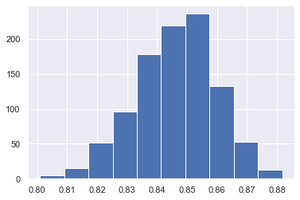

```
95.0 confidence interval 81.9% and 87.0%
```

```python
# plot scores

from matplotlib import pyplot
pyplot.hist(stats)
pyplot.show()
# confidence intervals
alpha = 0.95                             # for 95% confidence
p = ((1.0-alpha)/2.0) * 100              # tail regions on right and left .25 on each side indicated by P value (border)
lower = max(0.0, np.percentile(stats, p))
p = (alpha+((1.0-alpha)/2.0)) * 100
upper = min(1.0, np.percentile(stats, p))
print('%.1f confidence interval %.1f%% and %.1f%%' % (alpha*100, lower*100, upper*100))
```

### Using Random Forest Regressor

```python
values = df_XY.values
# Number of bootstrap samples to create
n_iterations = 1000
# size of a bootstrap sample
n_size = int(len(df_z) * 1)

# run bootstrap
# empty list that will hold the scores for each bootstrap iteration
stats = list()
for i in range(n_iterations):
    # prepare train and test sets
    train = resample(values, n_samples=n_size)  # Sampling with replacement
    test = np.array([x for x in values if x.tolist() not in train.tolist()])  # picking rest of the data not considered in sample


     # fit model
    rfTree = RandomForestRegressor(n_estimators=100)
    # fit against independent variables and corresponding target values
    rfTree.fit(train[:,:-1], train[:,-1])
    # Take the target column for all rows in test set

    y_test = test[:,-1]
    # evaluate model
    # predict based on independent variables in the test data
    score = rfTree.score(test[:, :-1] , y_test)
    predictions = rfTree.predict(test[:, :-1])

    stats.append(score)
```

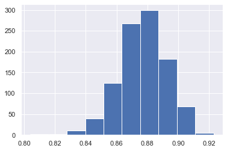

```
95.0 confidence interval 84.5% and 90.5%
```

```python
# plot scores

from matplotlib import pyplot
pyplot.hist(stats)
pyplot.show()
# confidence intervals
alpha = 0.95                             # for 95% confidence
p = ((1.0-alpha)/2.0) * 100              # tail regions on right and left .25 on each side indicated by P value (border)
lower = max(0.0, np.percentile(stats, p))
p = (alpha+((1.0-alpha)/2.0)) * 100
upper = min(1.0, np.percentile(stats, p))
print('%.1f confidence interval %.1f%% and %.1f%%' % (alpha*100, lower*100, upper*100))
```

The bootstrap random forest classification model performance is between 84.5% - 90.5% which is better than other classification algorithms used in this case.